# Meta-Analytic Structural Equation Modeling

Mike Cheung

8-10 Feb 2023 (Day 1, Session 2)

# A crash course in meta-analysis

## More and more academic papers are published every year

- Data and scientific findings are everywhere.
- An example using the keywords *personality* (top) and *intelligence* (bottom) between 1940 to 2020 from Scopus.

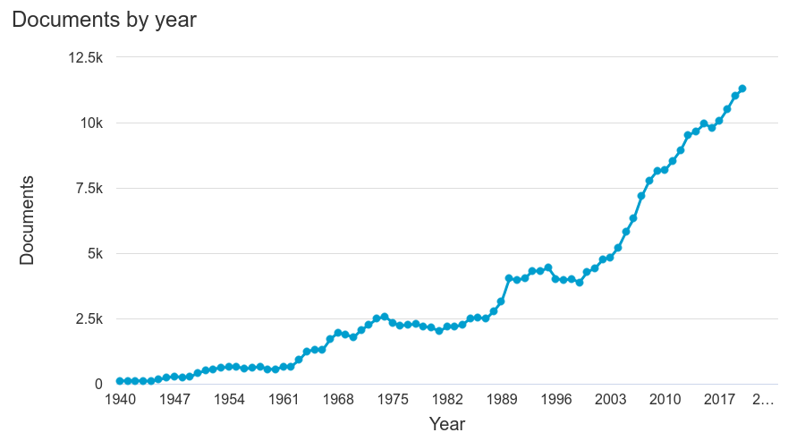

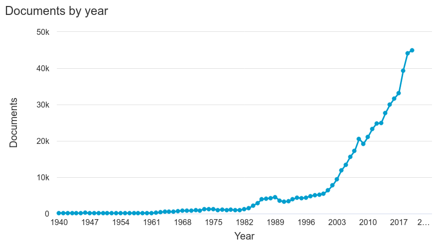

- If we are interested in the relationship between *personality* and *intelligence*, there are still thousands of papers.
- We may get a biased impression if we only read a few of them.

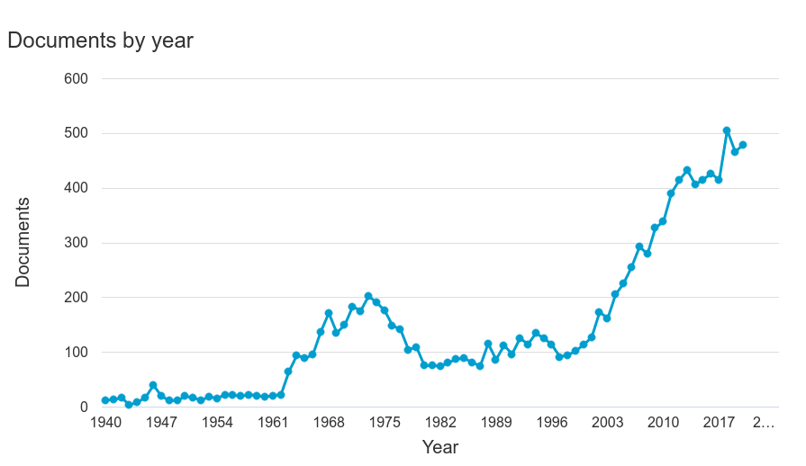

## Replication crisis (1)

- Some researchers argue that academic papers are likely biased due to publication bias and selective reporting.
- Replicability: the ability to rerun an experiment and get *consistent* results with the original study using new data (Patil, Peng, & Leek, 2016).[^1]
- An international collaboration team attempted to replicate 100 experimental and correlational studies published in psychology. They found that the replications tended to have larger *p*-values and smaller effect sizes (Open Science Collaboration, 2015).[^2]

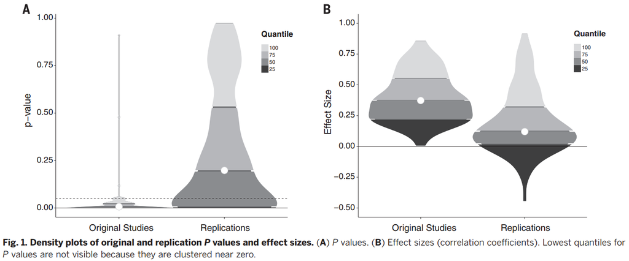

Open Science Collaboration (2015)

## Replication crisis (2)

- Published studies:
  - There are differences in research design, procedures, samples, and measures.
  - They are called *conceptual* replications.
- Replication studies:
  - The research design, procedures, samples, and measures are similar or identical across replications.
  - They are called *direct* replications.
- It has been found that findings in pre-registration and meta-analyses can be different (e.g., Kvarven, Strømland, & Johannesson, 2020).[^3]
- However, a recent large-scale review and meta-analysis suggests that the impact of publication bias is minimum (Stanley, Carter, & Doucouliagos, 2018).[^4]
- Meta-analysis can be used as a statistical method to analyze replications (e.g., Anderson & Maxwell, 2016; Hedges & Schauer, 2019).[^5], [^6]

## International projects and big data

- There are many large datasets freely available, e.g.,
  - [World Values Survey](https://www.worldvaluessurvey.org)
  - [International Social Survey Programme](https://issp.org/)
  - [National Longitudinal Surveys](https://www.nlsinfo.org/)
  - [PISA database](https://www.oecd.org/pisa/data/)
- Many open data initiates and big data, e.g., Twitter and Facebook, are freely accessible.

## Summary

- There is likely that some data are available for our research questions:
  - Academic journals (potentially biased effect sizes but peer-reviewed)
  - Pre-prints and dissertations (less biased effect sizes without any peer-reviewed)
  - Replications (less biased raw data)
  - Open data/archives/big data (raw data)
- An important question is how to use the existing data to address the research questions.

# What are systematic review and meta-analysis?

## Are systematic review and meta-analysis the same?

- Systematic review:
  - It aims to provide a comprehensive literature search with pre-defined eligibility criteria.
  - It focuses on minimizing bias in a literature review by using pre-defined criteria to replicate the literature search.
  - The main question is how to identify the relevant studies correctly.
- Meta-analysis:
  - It combines and synthesizes findings with statistical models.
  - The main question is how to analyze the quantitative data properly.
- There are 3 possible combinations:
  - A systematic review with a meta-analysis: A systematic review is conducted to minimize biases in the literature review. A meta-analysis is then conducted to summarize the findings statistically.
  - A systematic review without a meta-analysis: After completing a systematic review, it is found that there is not enough data or the effect sizes are too different for the meta-analysis.
  - A meta-analysis without a systematic review: An internal meta-analysis.

## Not all types of evidence are equal

- There is a hierarchy of evidence in medical science (e.g., Guyatt et al., 1995),[^7]
  - Experimental study: randomized control trials (participants are randomly assigned to vaccine vs. non-vaccine groups)
  - Observational study:
    - Cohort studies: recruit participants with and without vaccines and follow them to see if they will get COVID-19 in the future.
    - Case-control studies: recruit participants with and without COVID-19 and trace whether they have been vaccinated.
- In social sciences, we also have similar ideas, e.g.,
  - Meta-analysis > experimental studies > observational studies > case studies.

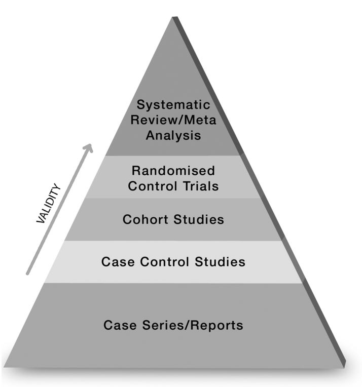

## Objectives of a meta-analysis

- Draw general conclusions on a particular topic.
- Test the homogeneity (consistency) of the existing findings.
- Account for the heterogeneity of effect sizes.
- Estimate an average effect size.
- Test potential moderators if the studies are heterogeneous.
- Assess the robustness of the findings, e.g., publication bias.

# Effect sizes and their sampling variances

## What is an effect size? (1)

- Effect sizes and their sampling variances are the building blocks of meta-analysis.
- Kelley and Preacher (2012) defined effect size “*as a quantitative reflection of the magnitude of some phenomenon that is used for the purpose of addressing a question of interest*” (p. 140, emphasis in original).
- The requirements of effect sizes in primary studies and meta-analyses can be different.
- There are 3 considerations:
  1. Strength
  2. Direction
  3. Independence of sample size
- Questions:
  1. Can a *t* statistic be used as an effect size in meta-analysis?
  2. Can an $R^2$ and $\Delta R^2$ in multiple regression be used as effect sizes in meta-analysis?
  3. Can an $\eta^2$ and $\omega^2$ in ANOVA be used as effect sizes in meta-analysis?
  4. Can a regression coefficient $\hat{\beta}$ be used as an effect size in meta-analysis?

## What is an effect size? (2)

- We use *y* and *v* to represent a generic effect size and its sampling variance. *y* can be a correlation coefficient, a standardized mean difference, or other effect sizes.
- Once we have calculated the effect sizes and their sampling variances, we may apply the same meta-analytic procedures to the data.

## What is an effect size? (3)

- There are various forms of effect sizes:
  - Unstandardized: using the original metrics (scales), e.g., raw or unstandardized mean difference and covariance
  - Standardized: using the SD of the variables, e.g., standardized mean difference, correlation, and standardized regression coefficients
  - Partially standardized: standardized some of the variables but not all, e.g., regression coefficients standardizing only the predictors
  - transformed: log odds ratio and Fisher’s z transformed score.
- It is crucial to choose the appropriate effect size for the meta-analysis.

## Common families of effect sizes

- There are three popular families:
  - *r*: Pearson correlation, which is popular in observational studies.
  - *d*: (standardized) mean difference, which is popular in experimental designs (control vs. intervention groups).
  - *OR*: odds ratio, which is popular in medical research with binary outcomes.

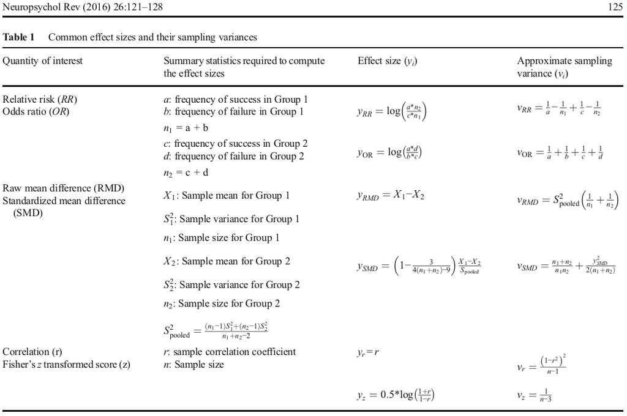

Cheung and Vijayakumar (2016, Table 1)

# Models for meta-analysis

- Generally, there are two models for meta-analysis—fixed- and random-effects models (e.g., Hedges & Vevea, 1998).[^11]

# Fixed-effect model

- Model: $y_i = \beta_\mathrm{F} + e_i$, where
  - $y_i$ is the observed effect size,
  - $\beta_\mathrm{F}$ is the population effect size under a fixed-effects model, and
  - $\mathrm{Var}(e_i)=v_i$ is the conditional sampling variance of $y_i$.
- All effect sizes are assumed to be equal across studies. It is also known as the common-effect model.
- There is only one unknown parameter $\beta_{F}$ in the model.
- $v_i$ is assumed to be known in each study. This assumption is reasonable when the sample sizes are reasonably large (say > 30).
- We cannot generalize the findings beyond the studies included in the meta-analysis.
- Three main tasks in a fixed-effect meta-analysis:
  - Estimate the common effect $\hat{\beta}_\mathrm{F}$.
  - Calculate the standard error of the estimated common effect $SE(\hat{\beta}_\mathrm{F})$.
  - Test whether the population effect sizes are homogeneous.

## Pooled effect size in a fixed-effect model

- $\hat{\beta}_\mathrm{F} = \frac{ \sum_{i=1}^{k} w_i y_i}{ \sum_{i=1}^{k} w_i}$ where $w_i=\frac{1}{v_i}$ is the weight and *k* is the number of studies.
- Sampling variance of $\hat{\beta}_\mathrm{F}$: $\mathrm{Var}(\hat{\beta}_\mathrm{F}) = SE^2_\mathrm{F} = \frac{1}{\sum_{i=1}^{k} w_i}$
- We may test whether the pooled effect size is statistically significant by using $z= \hat{\beta}_\mathrm{F}/SE_\mathrm{F}$, which has a standard normal distribution. If the absolute value of $z$ is larger than 1.96, it is statistically significant at .05.
- Reporting a confidence interval (CI) is usually preferred to a null hypothesis significance test (NHST). We may construct a 95% CI by,
  - 95% CI: $\hat{\beta}_\mathrm{F} \pm1.96SE_\mathrm{F}$.

## Homogeneity test of effect sizes

- Fixed-effects model is usually (but not always) assumed homogeneity of effect sizes, i.e., $H_0: \beta_\mathrm{F}=\beta_1=\beta_2=\cdots=\beta_k$.
- Under the assumption of homogeneity, the test statistic *Q* has a chi-square distribution with *df* = (no. of studies - 1),
  - $Q = \sum_{i=1}^{k} w_i(y_i-\hat{\beta}_\mathrm{F})^2$
- Like other NHST, the power of the Q statistic depends on the number of studies. If there are only a few studies, the test may not be powerful to reject the null hypothesis even if there is a large degree of heterogeneity. In contrast, the test is likely significant when there are lots of studies.
- Many researchers use $\alpha=.10$ rather than $\alpha=.05$.
- The choice of fixed-effect vs. random-effects model should not solely be based on the homogeneity test.
- When the studies are heterogeneous, $SE_\mathrm{F}$ *underestimates* the $SE_\mathrm{R}$ based on the random-effects model.

# Random-effects model

- The population effect sizes can differ across studies (Hedges & Vevea, 1998).[^12]
- The differences in the observed effect sizes are due to a combination of true difference (variance component) and sampling error.
- We can generalize the findings beyond the studies included in the meta-analysis.
- It is usually preferred in meta-analysis.
- Model: $y_i = \beta_\mathrm{R} + u_i + e_i$,
  - where $y_i$ is the observed effect size, $\beta_\mathrm{R}$ is the average population effect size under a random-effects model, and $\mathrm{Var}(e_i)=v_i$ is the conditional sampling variance of $y_i$, and $u_i$ is the study-specific random effect.
  - $\tau^2=\mathrm{Var}(u_i)$ is the variance of the random effects. It indicates the between-study heterogeneity.

## Differences between a fixed-effect and random-effects model (1)

- Borenstein et al. (2009)[^13] have provided illustrations between fixed-effect and random-effects models.

### Fixed-effect model

- All studies share the same common population effect $\beta_\mathrm{F}$ (circles).

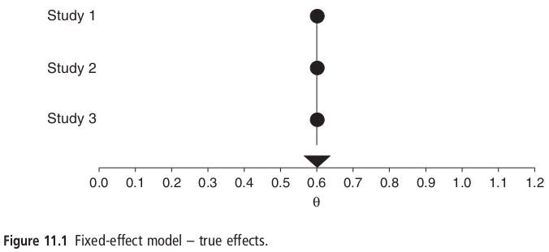

Borenstein et al. (2009, Figure 11.1)

- The observed differences in the sample effect sizes $y_i$ (squares) are only due to the sampling error with a variance of $v_i$.

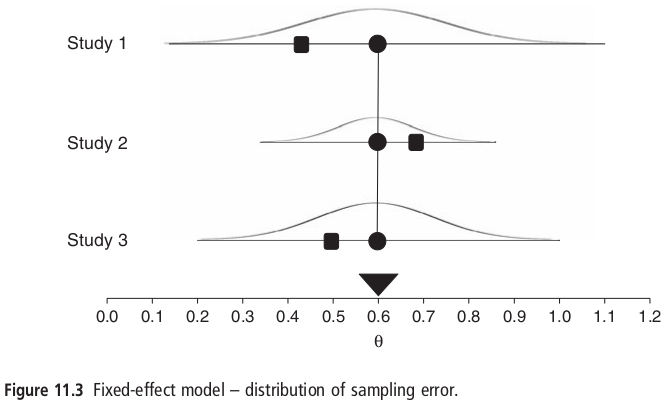

Borenstein et al. (2009, Figure 11.3)

### Random-effects model

- There is an average population effect $\beta_\mathrm{R}$ (triangle) with a distribution (Var=$\tau^2$)

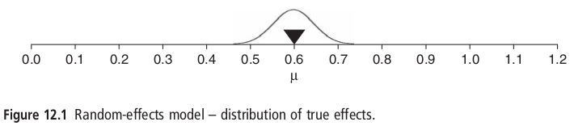

Borenstein et al. (2009, Figure 12.1)

- Each study has its own true population effect $\beta_i$ (circles), which are not observed by us. That is, the true population effect is latent.

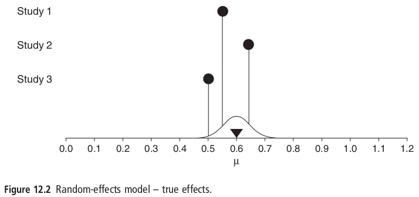

Borenstein et al. (2009, Figure 12.2)

- The sample effect sizes $y_i$ (squares) are conditionally sampled with $v_i$ due to the sampling error.

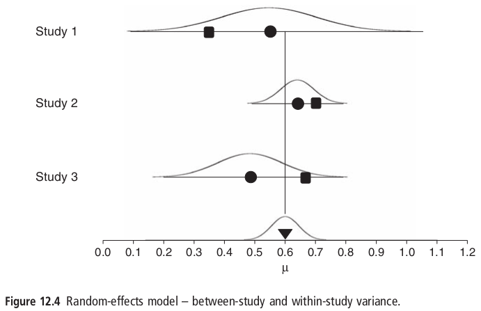

Borenstein et al. (2009, Figure 12.4)

## Differences between a fixed-effect and random-effects model (2)

- When the effect sizes are heterogeneous, we expect that they are more “varied.”

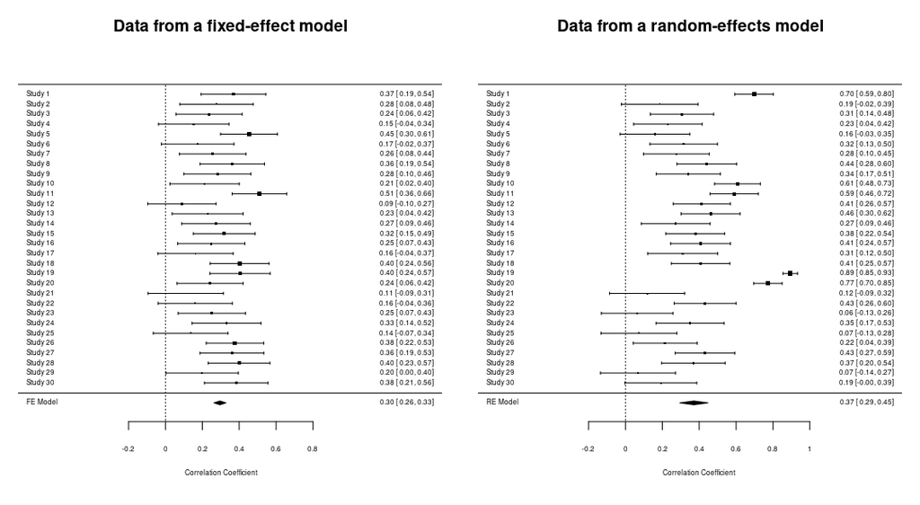

## Which estimator should we use?

- Viechtbauer (2005)[^14] did a comprehensive simulation and suggested that REML had a good compromise in bias and efficiency.
- Recent simulation studies show that the Hartung-Knapp-Sidik-Jonkman (HKSJ) method (Hartung & Knapp 2001; Sidik & Jonkman, 2006)[^15], [^16], which is called `method=SJ` in the metafor package, has good coverage properties.

## Parameter estimates under a random-effects model

- Once the estimated variance component $\hat{\tau}^2$ is available, we may compute a new weight $\tilde{w_i}=1/(v_i+\hat{\tau}^2)$.
- Then, we may apply what we have learned in the fixed-effects model.
- Average effect size:
  - $\hat{\beta}_\mathrm{R} = \frac{ \sum_{i=1}^{k} \tilde{w_i} y_i}{ \sum_{i=1}^{k} \tilde{w_i}}$ where $\tilde{w_i}=\frac{1}{v_i+\hat{\tau}^2}$.
  - Sampling variance of $\hat{\beta}_\mathrm{R}$ : $\mathrm{Var}(\hat{\beta}_\mathrm{R})=SE^2_\mathrm{R} = \frac{1}{\sum_{i=1}^{k} \tilde{w_i}}$
  - We may test whether the pooled effect size is statistically significant by using $z= \hat{\beta}_\mathrm{R}/SE_\mathrm{R}$, which has a standard normal distribution.

## Issues in interpreting $\tau^2$ (1)

- The value of $\tau^2$ cannot be compared across effect sizes because it depends on the type of effect size.
- Higgins and Thompson (2002)[^17] suggested three criteria for measuring heterogeneity:
  - Dependence on the extent of heterogeneity
  - Scale invariance ($\tau^2_r$ and $\tau^2_d$ should be comparable)
  - Size invariance (*k*; it does not depend on the number of studies)
  - *Note*. It does not say that it is sample size (*N*) invariance.

## Issues in interpreting $\tau^2$ (2)

- They further proposed several indices to quantify the degree of heterogeneity,
  - $I^2=\frac{Q-(k-1)}{Q}$.
  - When the estimated $I^2$ is negative, it is truncated to 0.
- An alternative way to express it is,
  - $I^2=\frac{\hat{\tau}^2}{\hat{\tau}^2 + \tilde{v_i}}$, where $\tilde{v_i}$ is the “average” sampling variance.
- It can be interpreted as the proportion of total variation due to heterogeneity between studies.
- As a rule of thumb, $I^2$ of 25%, 50%, and 75% can be considered as low, moderate, and high heterogeneity. This rule of thumb was based on meta-analyses of medical research. They may or may not be the same in other disciplines.
- When the sample sizes in the primary studies are getting larger and larger, $I^2$ approaches 1.
- *Note*. $\tau^2$ is an *absolute* measure of heterogeneity, whereas $I^2$ is a *relative* measure of heterogeneity depending on $\tilde{v_i}$ (Borenstein et al., 2017).[^18] It is advisable to report both indices.

## Confidence interval

- Confidence interval (CI):
  - A 95% confidence level represents the theoretical long-run frequency (i.e., 95% proportion) of confidence intervals that contain the true value of the unknown population parameter.
  - CIs can only be formed on parameters, e.g., $\beta_\mathrm{F}$, $\beta_\mathrm{R}$, and $\tau^2$.
  - For example, if the $\hat{\beta}_\mathrm{R}=.2$ and 95% CI = (.1, .3), $\hat{\beta}_\mathrm{R}$ is statistically significant at $\alpha=.05$.

## Why do researchers concern about the heterogeneity of studies?

- Do you prefer homogeneous or heterogeneous findings? Why?

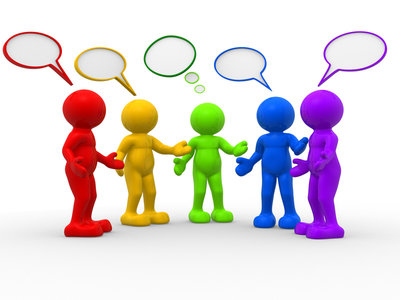

- What are the implications of homogeneous findings?
- What are the implications of heterogeneous findings?

# Exploring heterogeneity

- Why the effect sizes are heterogeneous?
  - Sampling error (bad luck!)
  - Measurement artifacts, e.g., unreliability, range restriction, differences in samples, measures, etc.
  - Presence of moderators, e.g., samples, measures, etc.
- When there is excess heterogeneity, we may want to model the effect sizes with the study characteristics.
- A subgroup analysis and mixed-effects model are the common technique to do it.

## Subgroup analysis

- If the moderator is a categorical variable, e.g., experimental vs. observational, we may run a separate meta-analysis on each level.
- Advantages:
  - It is simple.
  - Different groups may have different estimates of heterogeneity variances.
- Disadvantages:
  - It is slightly more complicated if we want to test whether the categorical variable is statistically significant.
  - It does not provide an $R^2$ on the moderator.
- Readers may refer to Rubio-Aparicio et al. (2020)[^19] for a comparison between the subgroup analysis and meta-regression in handling categorical moderators.

## Mixed-effects model

- Mixed-effects model or meta-regression may be used to explore the heterogeneity (Konstantopoulos & Hedges, 2004).[^20]
- The study characteristics are known as the covariates, predictors, or *moderators* in meta-analysis.
- Ideally, we should formulate the moderators *a priori* before the analyses.
  - For example, Cheng, Cheung, and Lo (2016)[^21] did a literature review and selected four moderators (gender and age compositions, individualism, and power distance) for testing.
  - The main advantage is that we can report and discuss the findings regardless of whether they are significant.

### Model

- Study characteristics may be in the form of:
  - Categorical, e.g., experimental vs. observational studies
  - Continuous, e.g., year of publication, duration of the intervention
- Model: $y_i = \beta_0 + \beta_1 x_{1i} + u_i + e_i$,
  - where $y_i$ is the observed effect size, $\beta_0$ is the intercept, $\mathrm{Var}(e_i)=v_i$ is the conditional sampling variance of $y_i$, and $u_i$ is the study-specific random effect.

### Explained variance

- We may calculate an $R^2$ index: $R^2=\frac{\tau^2_0-\tau^2_1}{\tau^2_0}$, where $\tau^2_0$ and $\tau^2_1$ are the heterogeneity variances without and with the predictors.
- A few issues to note:
  - It is possible that $R^2$ is negative. If it happens, it is truncated to zero.
  - If there are missing values in the covariates, these cases have to be excluded before calculating the heterogeneity variances; otherwise, these two estimates will be based on different numbers of studies.
  - The covariate may be statistically significant, but the $R^2$ can be small and vice versa.

### Ecological inference

- Special care must be taken to avoid an ecological fallacy—incorrectly interpreting findings from the aggregated statistics as findings from the individuals.
- Use the proportion of females as an example.
  - If it positively predicts the odds ratio of having a disease, it is tempting to interpret that females are more likely to get the disease than males.
  - As the predictor is the proportion of females (not gender at the individual level), there are still males in studies with a high proportion of females.
  - What the result suggests is that studies with more females are more likely to have larger odds ratios. This effect may or may not be attributed to the female participants in these studies.
- Another common mistake is interpreting the mean age of participants as the age of the participants.

## Pictorial models on fixed-, random-, and mixed-effects models

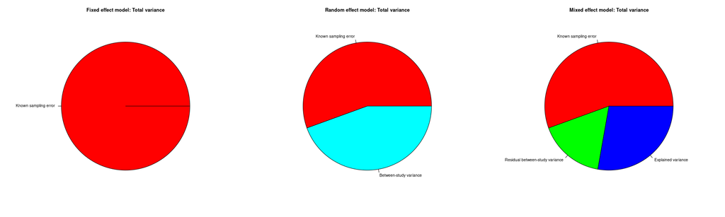

# Publication bias and sensitivity analysis

## Potential issues in meta-analysis

- Although meta-analysis is a very powerful technique, it is not without issues.
- Combining apples and oranges:
  - Studies are usually with various designs, samples and measures.
  - The combined effect size may sometimes not make sense.
- Possible solutions:
  - Clearer definitions of inclusion criteria;
  - Designs and samples as potential moderators, e.g., experimental vs. observational studies, cultural groups (cross-cultural meta-analysis)

## Publication bias

- Studies with significant effects are more likely to be published than those without significant effects:
  - Authors are less likely to work on papers with non-significant findings.
  - Reviewers/editors are less likely to accept papers with non-significant findings.
- Marks-Anglin and Chen (2020) provided a comprehensive overview of different techniques for assessing publication bias.[^22]
- A few notes:
  - These methods are based on different assumptions with different objectives. Thus, their conclusions may not be the same.
  - Graphical methods are visually appealing but potentially subjective, whereas statistical methods usually rely on strong assumptions.
  - Different reviewers and action editors may have different requirements.

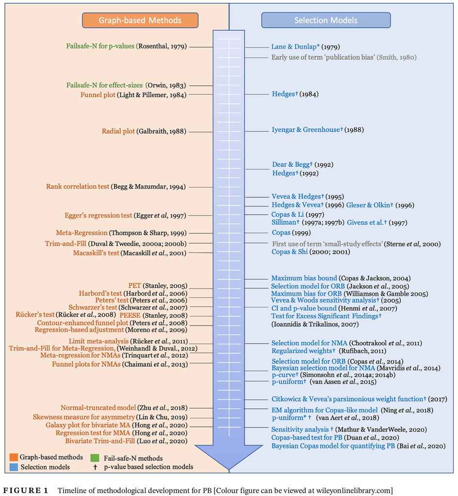

Marks-Anglin and Chen (2020, Figure 1)

### Unpublished work or gray literature

- Examples of unpublished work include dissertations, conference presentations, proceedings, technical reports, and preprints. There are pros and cons to having unpublished work.
- Against including unpublished work (e.g., Ferguson & Brannick, 2012):[^23]
  1. Unpublished studies may be of weaker methodology,
  2. The included unpublished studies may be biased towards the authors conducting the meta-analyses because of the ease of availability of these studies (this is true based on my review experience!),
  3. Searches for unpublished studies may favor established rather than non-established authors,
  4. The search for unpublished studies may also be biased.
- For including unpublished work (e.g., Rothstein & Bushman, 2012):[^24]
  1. Studies may be excluded on the methodological rigorousness by using clearly defined inclusion criteria rather than excluding all unpublished studies,
  2. Researchers may try to contact the authors who have published on the topic to minimize potential selection bias,
  3. Researchers should include unpublished studies and test whether study characteristics related to methodological quality moderate the effect sizes.
- Suggestions:
  - Include dissertations (searched via ProQuest through your library) if possible.
  - Code published vs. unpublished and test how robust the findings are with and without the unpublished work.

## An example in R:

- Jaramillo et al. (2005)[^25] conducted a meta-analysis of 61 studies on the relationship between organizational commitment and salesperson job performance.
- The effect size was a correlation coefficient.
- Potential covariates:
  - Individualism scores (`IND`) of the participants of the studies
  - Type of sales (`Sales`) of the participants

### Data and descriptive statistics

```r
## Library to conduct the meta-analysis
library(metaSEM)

## Show the first few cases
head(Jaramillo05)
```

```
##                        Author Sample_size    Sales Country IDV         OC_scale
## 1         Aryee et al. (2002)         179    mixed   India  48 Porter or Mowday
## 2 Balfour and Wechsler (1991)         232 nonsales     USA  91            other
## 3     Bashaw and Grant (1994)         560    sales     USA  91 Porter or Mowday
## 4             Benkhoff (1997)         181    sales Germany  67 Porter or Mowday
## 5         Brett et al. (1995)         156    sales     USA  91 Porter or Mowday
## 6         Brett et al. (1995)         180    sales     USA  91 Porter or Mowday
##   OC_alpha JP_alpha    r         r_v
## 1     0.87     0.89 0.02 0.005582124
## 2     0.82       NA 0.12 0.004187101
## 3     0.83     0.76 0.09 0.001756903
## 4       NA     1.00 0.20 0.005091713
## 5     0.83       NA 0.08 0.006328468
## 6     0.83       NA 0.04 0.005537792
```

## Fixed-effects model

- Since the fixed-effects model is a special case of the random-effects model by constraining the $\tau^2=0$, we may use the following code to test the model.
- The homogeneity test is $Q(df=60)=339.39, p < .001$, which is significant. It is questionable to apply the fixed-effects model.
- The pooled effect size with its 95% CI is 0.19 (0.18, 0.21). Note. The CIs are likely under-estimated when the effect sizes are heterogeneous!

```r
## RE.constraints=0: tau^2=0
summary( meta(y=r, v=r_v, data=Jaramillo05, RE.constraints=0) )
```

```
##
## Call:
## meta(y = r, v = r_v, data = Jaramillo05, RE.constraints = 0)
##
## 95% confidence intervals: z statistic approximation (robust=FALSE)
## Coefficients:
##             Estimate Std.Error    lbound    ubound z value  Pr(>|z|)
## Intercept1 0.1937681 0.0079323 0.1782212 0.2093151  24.428 < 2.2e-16 ***
## ---
## Signif. codes:  0 '***' 0.001 '**' 0.01 '*' 0.05 '.' 0.1 ' ' 1
##
## Q statistic on the homogeneity of effect sizes: 339.3886
## Degrees of freedom of the Q statistic: 60
## P value of the Q statistic: 0
##
## Heterogeneity indices (based on the estimated Tau2):
##                              Estimate
## Intercept1: I2 (Q statistic)        0
##
## Number of studies (or clusters): 61
## Number of observed statistics: 61
## Number of estimated parameters: 1
## Degrees of freedom: 60
## -2 log likelihood: 129.0697
## OpenMx status1: 0 ("0" or "1": The optimization is considered fine.
## Other values may indicate problems.)
```

## Random-effects model

- The random-effects model is more appropriate.
- The estimated heterogeneity variance ($\tau^2$) is .017, and the $I^2$ is .81, meaning that the between-study heterogeneity explains 81% of the variation of the effect size.
- The average effect size with its 95% CI is 0.19 (0.15, 0.22). Note. The CIs are usually larger than those based on the fixed-effects model.

```r
## Random-effects model
model0 <- meta(y=r, v=r_v, data=Jaramillo05)
summary(model0)
```

```
##
## Call:
## meta(y = r, v = r_v, data = Jaramillo05)
##
## 95% confidence intervals: z statistic approximation (robust=FALSE)
## Coefficients:
##             Estimate Std.Error    lbound    ubound z value  Pr(>|z|)
## Intercept1 0.1866221 0.0193303 0.1487354 0.2245088  9.6544 < 2.2e-16 ***
## Tau2_1_1   0.0170341 0.0041352 0.0089292 0.0251389  4.1193 3.801e-05 ***
## ---
## Signif. codes:  0 '***' 0.001 '**' 0.01 '*' 0.05 '.' 0.1 ' ' 1
##
## Q statistic on the homogeneity of effect sizes: 339.3886
## Degrees of freedom of the Q statistic: 60
## P value of the Q statistic: 0
##
## Heterogeneity indices (based on the estimated Tau2):
##                              Estimate
## Intercept1: I2 (Q statistic)   0.8144
##
## Number of studies (or clusters): 61
## Number of observed statistics: 61
## Number of estimated parameters: 2
## Degrees of freedom: 59
## -2 log likelihood: -55.44225
## OpenMx status1: 0 ("0" or "1": The optimization is considered fine.
## Other values may indicate problems.)
```

## Mixed-effects model

- We consider `IND` as a moderator.
- We usually center the moderators before the analysis.
- The $R^2=.04$ meaning that `IND` explains about 4% of the between-study heterogeneity.
- The estimated regression coefficient with its 95% CI is -0.001 (-0.00, 0.00), which is not significant.

```r
## Center IDV for ease of interpretation: scale(IDV, scale=FALSE)
model1 <- meta(y=r, v=r_v, x=scale(IDV, scale=FALSE), data=Jaramillo05)
summary(model1)
```

```
##
## Call:
## meta(y = r, v = r_v, x = scale(IDV, scale = FALSE), data = Jaramillo05)
##
## 95% confidence intervals: z statistic approximation (robust=FALSE)
## Coefficients:
##               Estimate   Std.Error      lbound      ubound z value  Pr(>|z|)
## Intercept1  0.18596328  0.01903036  0.14866446  0.22326210  9.7719 < 2.2e-16
## Slope1_1   -0.00132138  0.00097695 -0.00323617  0.00059341 -1.3526    0.1762
## Tau2_1_1    0.01634054  0.00402026  0.00846097  0.02422010  4.0645 4.813e-05
##
## Intercept1 ***
## Slope1_1
## Tau2_1_1   ***
## ---
## Signif. codes:  0 '***' 0.001 '**' 0.01 '*' 0.05 '.' 0.1 ' ' 1
##
## Q statistic on the homogeneity of effect sizes: 339.3886
## Degrees of freedom of the Q statistic: 60
## P value of the Q statistic: 0
##
## Explained variances (R2):
##                            y1
## Tau2 (no predictor)    0.0170
## Tau2 (with predictors) 0.0163
## R2                     0.0407
##
## Number of studies (or clusters): 61
## Number of observed statistics: 61
## Number of estimated parameters: 3
## Degrees of freedom: 58
## -2 log likelihood: -57.24231
## OpenMx status1: 0 ("0" or "1": The optimization is considered fine.
## Other values may indicate problems.)
```

# Summary

- It is challenging to draw conclusions based on a few primary studies.
- Systematic review and meta-analysis provide a valuable approach to synthesizing research findings.
- Random-effects model is a useful approach to analyzing the data.
[^1]: Patil, P., Peng, R. D., & Leek, J. (2016). A statistical definition for reproducibility and replicability. *bioRxiv*, 66803.
[^2]: Open Science Collaboration (2015). Estimating the reproducibility of psychological. *Science*, *349* (6251), aac4716.
[^3]: Kvarven, A., Strømland, E., & Johannesson, M. (2020). Comparing meta-analyses and preregistered multiple-laboratory replication projects. *Nature Human Behaviour*, 4(4), 423–434. https://doi.org/10.1038/s41562-019-0787-z
[^4]: Stanley, T. D., Carter, E. C., & Doucouliagos, H. (2018). What meta-analyses reveal about the replicability of psychological research. *Psychological Bulletin*, *144*(12), 1325–1346. https://doi.org/10.1037/bul0000169
[^5]: Anderson, S. F., & Maxwell, S. E. (2016). There’s more than one way to conduct a replication study: Beyond statistical significance. *Psychological Methods*, *21*(1), 1–12. https://doi.org/10.1037/met0000051
[^6]: Hedges, L. V., & Schauer, J. M. (2019). Statistical analyses for studying replication: Meta-analytic perspectives. *Psychological Methods*, *24*(5), 557–570. https://doi.org/10.1037/met0000189
[^7]: Guyatt, G. H., Sackett, D. L., Sinclair, J. C., Hayward, R., Cook, D. J., Cook, R. J., Bass, E., Gerstein, H., Haynes, B., Holbrook, A., Jaeschke, R., Laupacls, A., Moyer, V., & Wilson, M. (1995). Users’ Guides to the Medical Literature: IX. A Method for Grading Health Care Recommendations. *JAMA*, *274*(22), 1800–1804. https://doi.org/10.1001/jama.1995.03530220066035
[^8]: Hedges, L. V. (1981). Distribution theory for Glass’s estimator of effect size and related estimators (Hedges, 1981). *Journal of Educational and Behavioral Statistics*, *6*(2), 107–128. https://doi.org/10.3102/10769986006002107
[^9]: Schmidt, F. L., & Hunter, J. E. (2015). *Methods of meta-analysis: Correcting error and bias in research findings* (3rd ed.). Sage.
[^10]: Hedges, L. V., & Olkin, I. (1985). *Statistical methods for meta-analysis*. Orlando, FL: Academic Press.
[^11]: Hedges, L. V., & Vevea, J. L. (1998). Fixed- and random-effects models in meta-analysis. *Psychological Methods*, *3*(4), 486–504. https://doi.org/10.1037/1082-989X.3.4.486
[^12]: Hedges, L. V., & Vevea, J. L. (1998). Fixed- and random-effects models in meta-analysis. *Psychological Methods*, *3*, 486-504.
[^13]: Borenstein, M., Hedges, L. V., Higgins, J. P. T., & Rothstein, H. R. (2009). *Introduction to meta-analysis*. John Wiley & Sons.
[^14]: Viechtbauer, W. (2005). Bias and efficiency of meta-analytic variance estimators in the random-effects model. *Journal of Educational and Behavioral Statistics*, *30*(3), 261–293. https://doi.org/10.3102/10769986030003261
[^15]: Hartung, J., & Knapp, G. (2001). On tests of the overall treatment effect in meta-analysis with normally distributed responses. *Statistics in Medicine*, *20*(12), 1771–1782. https://doi.org/10.1002/sim.791
[^16]: Sidik, K., & Jonkman, J. N. (2006). Robust variance estimation for random effects meta-analysis. *Computational Statistics & Data Analysis*, *50*(12), 3681–3701. https://doi.org/10.1016/j.csda.2005.07.019
[^17]: Higgins, J. P. T., & Thompson, S. G. (2002). Quantifying heterogeneity in a meta-analysis. *Statistics in Medicine*, *21*, 1539-1558.
[^18]: Borenstein, M., Higgins, J. P. T., Hedges, L. V., & Rothstein, H. R. (2017). Basics of meta-analysis: I2 is not an absolute measure of heterogeneity. *Research Synthesis Methods*, *8*(1), 5–18. https://doi.org/10.1002/jrsm.1230
[^19]: Rubio-Aparicio, M., López-López, J. A., Viechtbauer, W., Marín-Martínez, F., Botella, J., & Sánchez-Meca, J. (2020). Testing categorical moderators in mixed-effects meta-analysis in the presence of heteroscedasticity. *The Journal of Experimental Education*, *88*(2), 288–310. https://doi.org/10.1080/00220973.2018.1561404
[^20]: Konstantopoulos, S., & Hedges, L. V. (2004). [Meta-analysis](http://www.sesp.northwestern.edu/docs/publications/27535079044f49a7a596c5.pdf). In D. Kaplan (Ed.), *Handbook of quantitative methodology for the social sciences* (pp. 281-297). New York: Sage.
[^21]: Cheng, C., Cheung, M. W.-L., & Lo, B. C. Y. (2016). Relationship of health locus of control with specific health behaviours and global health appraisal: A meta-analysis and effects of moderators. *Health Psychology Review*, *10*.(4), 460–477. https://doi.org/10.1080/17437199.2016.1219672
[^22]: Marks‐Anglin, A., & Chen, Y. (2020). A historical review of publication bias. *Research Synthesis Methods*, *11*(6), 725–742. https://doi.org/10.1002/jrsm.1452
[^23]: Ferguson, C. J., & Brannick, M. T. (2012). Publication bias in psychological science: Prevalence, methods for identifying and controlling, and implications for the use of meta-analyses. *Psychological Methods*, *17(1)*, 120-128.
[^24]: Rothstein, H. R., & Bushman, B. J. (2012). Publication Bias in Psychological Science: Comment on Ferguson and Brannick (2012). *Psychological Methods*, *17(1)*, 129-136.
[^25]: Jaramillo, F., Mulki, J. P., & Marshall, G. W. (2005). A meta-analysis of the relationship between organizational commitment and salesperson job performance: 25 years of research. *Journal of Business Research*, *58(6)*, 705–714. https://doi.org/10.1016/j.jbusres.2003.10.004